# S2.7: la simulazione a pezzi dentro il simulatore dà lo stesso vetrino della simulazione in un pezzo solo, nel tempo e nella memoria del bilancio?

geo_spatialtrans, report di step (protocollo v2)

Published

November 11, 2026

# In breve

## In breve: la simulazione a pezzi dentro il simulatore dà lo stesso vetrino della simulazione in un pezzo solo, nel tempo e nella memoria del bilancio?

**A cosa serviva.** Un vetrino vero copre circa 45 mm². Il simulatore di oggi lo regge in un pezzo solo solo per tre tessuti su cinque, e la simulazione a pezzi provata la volta scorsa sbagliava alle giunture: cellule simulate due volte, coda lunga dei trascritti ripiegata dentro ogni pezzo. Qui abbiamo scritto dentro il simulatore una simulazione a pezzi in cui ogni cellula si simula una volta sola e i trascritti che escono da un pezzo passano al pezzo dove arrivano. Poi abbiamo controllato che dia lo stesso risultato del pezzo solo e del simulatore di oggi, e quanto costa.

**Cosa abbiamo trovato.**

1. **Il risultato non dipende più da come si taglia il vetrino: a pezzi e in un pezzo solo i file sono identici, bit per bit.**
   - Lo abbiamo verificato su quadrati di 4 mm² dei sei tessuti, sulla sezione intera del cuore e sulle sezioni del tumore del colon e del cervello, con pezzi da mezzo millimetro e da un millimetro e con un numero diverso di processi.
   - Le giunture non esistono più come difetto: fra i pezzi di una sezione passano da 5 a 52 milioni di trascritti e nessuno si perde.
2. **Il simulatore a pezzi riproduce quello di oggi: UMI e geni per quadratino coincidono entro il 2 % in tutti i sei tessuti.**
   - Nel cervello, con nove ripetizioni, il nuovo dava l’1,6 % in più. Con 27 ripetizioni lo scarto scende allo 0,4 %: era il caso.
   - La prova vede una differenza quando c’è: abbassando apposta la cattura del 5 %, la vede in tutti e sei i tessuti.
3. **Sulle sezioni intere il vetro lontano dal tessuto ora è giusto.**
   - Nell’intestino, nel linfonodo e nel cuore la sezione a pezzi coincide con quella in un pezzo solo: nel tessuto entro l’1 %. Sul vetro a più di mezzo millimetro dal tessuto, nell’intestino e nel linfonodo, entro il 2 %. Prima, a pezzi, quel vetro aveva la metà dei trascritti.
   - Ora si simulano anche il tumore del colon e il cervello, che in un pezzo solo non stavano nella memoria del server.
4. **La memoria sta nel bilancio con pezzi da mezzo millimetro; il tempo no, nel tumore e nell’intestino.**
   - Con pezzi da un millimetro un pezzo del tumore usa 12,5 GB e uno del cervello 9,6, sopra gli 8 GB del bilancio. Con pezzi da mezzo millimetro scendono sotto i 4 GB e il risultato è lo stesso. Ho reso il mezzo millimetro il valore predefinito.
   - Per mm² di tessuto il tumore costa 6 minuti e mezzo e l’intestino 5 e mezzo, contro i 5 del bilancio; linfonodo, cervello e cuore stanno sotto. Una sezione intera del tumore richiede 3 ore e mezza di processore, mezz’ora con 8 processi. Da un sesto a due terzi del tempo va nel calcolo esatto di quanta parte di ogni quadratino copre ogni cellula.
5. **Il tetto ai trascritti generati per le strisce funziona, e abbiamo trovato e corretto un errore del simulatore di oggi.**
   - Con il tetto fisso che hai scelto, sulla sezione del linfonodo si generano 265 milioni di trascritti invece di 496. Il taglio tocca circa un quadratino su 100 000 e meno di 6 UMI su un milione.
   - Sulle aree molto grandi il simulatore di oggi poteva attribuire alcuni trascritti al gene sbagliato. Nelle sezioni intere simulate la volta scorsa in un pezzo solo era successo a circa l’1,3 % dei trascritti nell’intestino e nel linfonodo. Il numero totale di trascritti non cambiava, e le conclusioni di allora usavano solo quello. Ora è corretto, e la cellula del linfonodo che bloccava il calcolo dei triangoli si gestisce da sola.

**Cosa devi decidere.**

1. **Accettiamo che tumore del colon e intestino costino più di 5 minuti per mm² di tessuto? Consiglio di sì, come limite dichiarato.**
   - Una sezione intera resta fattibile in mezz’ora con 8 processi, e la memoria è nel bilancio.
   - Il guadagno possibile sta nel calcolo esatto delle coperture e nella posizione dei trascritti. È lavoro di ottimizzazione da fare insieme a quella del livello delle cellule, già in coda.
   - Alternativa: un passo di ottimizzazione subito, prima di chiudere lo Step 2. Costa un altro step e rimanda la revisione d’insieme.

**Comunque**: quando chiuderemo lo Step 2 sceglieremo quale delle due funzioni, quella a pezzi o quella di oggi, diventa l’ingresso del pacchetto. In quell’occasione scriveremo anche nella guida che il riquadro dell’area vale come bordo aperto sia per la coda lunga sia per la distanza dal bordo del tessuto. La prova del riquadro della finestra nell’intestino, rimasta indietro, si fa lì.

Appena decidi questo punto, lo step è chiuso.

**Sui tempi di calcolo.** Li ho misurati io sul server: 26 ore-processo per le prove pre-registrate, contro le 21 stimate, più 9 per le verifiche successive. In tutto circa 4 ore di orologio, con al massimo 16 processi e la temperatura al massimo di 82 °C. Una prima esecuzione di circa un’ora e mezza è stata cancellata e rifatta, dopo aver tolto una lentezza del codice che non cambiava i risultati.

# Dubbi rinviati

| cosa | perché | cosa serve per chiuderlo | step destinatario | voce di BACKLOG |
| --- | --- | --- | --- | --- |
| tempo per mm² di tessuto oltre il bilancio nel tumore (388 s) e nell’intestino (330 s) | verità geometrica esatta (fino al 37 %) e posizione dei trascritti | decisione di Luca (limite dichiarato o ottimizzazione); ottimizzazione della verità geometrica con BL-243 | da assegnare (con S1.7) | BL-246 |
| impronta della ripresa senza versione del codice; `truth$layers$stripes$M` grezzo accanto a M* | uscite e ripresa della funzione nuova | versione del codice nell’impronta; nomi chiari delle uscite | consolidamento dello Step 2 | BL-247 |
| `frame` vale anche per la distanza dal bordo; fondo con il fattore tagliato; descrittiva BL-237 non fatta | documentazione e prova descrittiva | guida d’uso; area A1_r1 con il riquadro della finestra | consolidamento dello Step 2 | BL-248 |

# Cancelli, previsioni e controprova

Pre-registrazione: cancelli `371a1ea`; ok di Luca sulle previsioni, sulle soglie, sul tetto fisso per tessuto e sul calcolo il 2026-11-10 («Ok, come proposte (Recommended)»; «Tetto fisso per tessuto (Recommended)»), commit `12aec8a`. Correzioni prima dei calcoli `c8d6c5e`. Codice delle esecuzioni `d5e0cfa`. File dello step: `docs/steps/S2.7.md`.

Tabelle in `results/S2.7/`: `S2.7_G1_tests.txt`, `S2.7_mutants.txt`, `S2.7_G2_identity.csv`, `S2.7_G4_test_S2.*.txt`, `S2.7_md5_before.txt`, `S2.7_md5_after.txt`, `S2.7_P1.csv`, `S2.7_section_<A>.csv`, `S2.7_P3_P4.csv`, `PH1/S2.7_P1.csv`, `S2.7_PH2_md5.txt`, `S2.7_PH_A1*.csv`. Uscite grezze in `/mnt/micron/geo_spatialtrans/S2.7/` (`G2/`, `p1/`, `sections/`, `p1ph/`, `sections_ph/`). Codice delle esecuzioni: commit `d5e0cfa`.

### Cancelli

- **G-1** superato: batteria 78/78 sul codice finale; mutanti 8/8 (prima stesura 6/8, correzione C-1).
- **G-2** superato: 210 confronti di impronte, 210 identici (sei quadrati di 4 mm², pezzo solo contro pezzi di 504 e 1 008 µm con 4 processi; sezione intera del cuore, pezzo solo contro pezzi di 1 008 µm con 8 e 3 processi e di 504 µm con 8). Il revisore dei numeri ha confrontato byte per byte 75 coppie di file: nessuna differenza.
- **G-3** superato: in 108 esecuzioni della funzione nuova tutti i controlli scritti dalla funzione sono veri (ogni cellula in un solo pezzo, ogni quadratino una volta, conservazione per cellula e totale, UMI = catturati + fondo, nessun NA, somma a 8 µm). Due di questi controlli sono veri per costruzione (vedi la revisione, R-04); quello che rileva i trascritti persi fra pezzi è la conservazione per cellula (mutante M2). Un ripiego della triangolazione in tutto: la cellula 624286 della sezione del linfonodo.
- **G-4** superato: 192 file letti identici prima e dopo; `R/` cambiato solo nei file dichiarati; batterie di S2.1…S2.6 invariate (21, 36, 39, 37, 40, 33 asserzioni, nessun FAIL).
- **G-5** superato: due revisori, nessuna discrepanza numerica, nessun difetto che cambi i risultati (sotto «Revisione avversariale»).

### Previsioni

| id | giudizi | conf. | indet. | smentite | in breve |
| --- | --- | --- | --- | --- | --- |
| P-1 stessa legge del motore di S2.5 (1 mm²) | 24 | 21 | 3 | 0 | cervello UMI e geni 1.016 [1.003, 1.030], 1.016, 1.014: tutte e tre per eccesso; con 27 semi 1.004 [0.995, 1.014], confermate (PH-1) |
| P-2 sezioni a pezzi / pezzo solo di S2.6 | 14 | 13 | 1 | 0 | tessuto 0.999, 1.001, 1.002; vetro oltre 512 µm 1.018 (intestino), 1.013 (linfonodo); cuore 256-512 µm 1.26 [1.15, 4.0] su 108 blocchi all’angolo (34 contro 27 UMI) |
| P-3a picco per pezzo, pezzi di 1 008 µm | 5 | 3 | 0 | 2 | tumore 12.5 GB, cervello 9.6 GB (fase B); con pezzi di 504 µm 3.8 e 3.4 GB (PH-2) |
| P-3b tempo di processo per mm² di tessuto | 5 | 3 | 0 | 2 | intestino 330 s, tumore 388 s; linfonodo 233, cervello 263, cuore 72 |
| P-4 quota troncata dal tetto | 5 | 5 | 0 | 0 | da 4.8e-7 a 5.3e-6; da 142 a 267 quadratini sopra il tetto per sezione |

P-3 è un solo seme: la stima è l’esito, senza errore Monte Carlo (dichiarato).

### Controprova

- **CP-1** superata: UMI per quadratino delle uscite dei pezzi assottigliate a 0.95, smentita per difetto in 6/6 (da 0.947 a 0.965; cervello 0.965 [0.953, 0.978]).

### Misure (senza intervallo)

- Trascritti passati fra pezzi nelle sezioni: da 4.6 milioni (cuore) a 52 milioni (cervello); generati: linfonodo 265 milioni contro 496 della sezione in un pezzo solo di S2.6.
- Tempo per fase (sezioni, pezzi di 1 008 µm, 8 processi): verità geometrica da 1 390 a 2 750 s (dal 17 % del tempo nel tumore al 69 % nel cuore); orologio da 7 a 32 minuti; processo principale fino a 34 GB (tumore, cucitura). Tetto M*: 4.13, 4.70, 4.04, 3.81, 2.98 (intestino, tumore, linfonodo, cervello, cuore).
- Quadrati di 4 mm² in un pezzo solo (G-2): da 249 s (cuore) a 1 382 s (tumore), contro 238-1 190 s del motore di S2.5 in S2.6; a pezzi, tempo di processo da 1.1 a 1.7 volte il pezzo solo (504 e 1 008 µm).
- Non fatte: descrittive di BL-237 (riquadro della finestra in A1_r1) e descrittive delle sezioni contro il vero oltre a quelle nelle tabelle delle sezioni (colonne `ratio_pieces_real`): vedi «Deviazioni».

## Figure

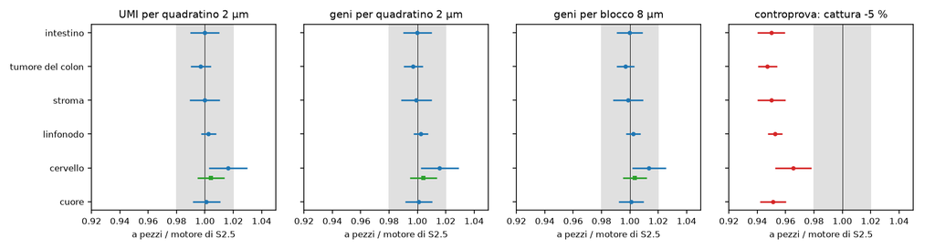

P-1 e controprova: rapporto fra la simulazione a pezzi e il motore di S2.5 sulla prima area di 1 mm² di ogni tessuto (media sui semi, ± 2 errori standard). Banda grigia: margine del 2 %. Quadrato verde: cervello con 27 semi (PH-1).

**Cosa guardare**: tutti i punti blu stanno nella banda; il cervello con 9 semi tocca il bordo e con 27 torna su 1; la controprova rossa sta fuori in tutti i tessuti.

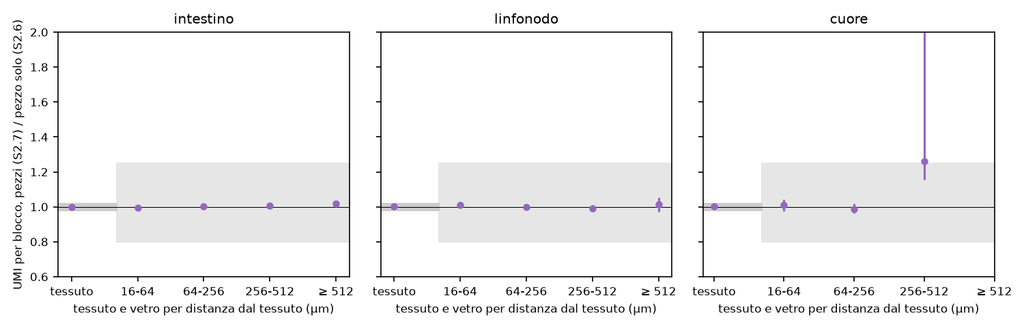

P-2: sezioni intere a pezzi diviso le sezioni in un pezzo solo di S2.6, tessuto e vetro per distanza dal tessuto, intervallo percentile del bootstrap delle tessere di 500 µm (troncato a 2). Grigio scuro: margine del tessuto (± 2 %); grigio chiaro: margine del vetro (0.8-1.25).

**Cosa guardare**: il vetro lontano dell’intestino e del linfonodo, che in S2.6 a pezzi aveva la metà dei trascritti, ora coincide; resta largo solo l’angolo del cuore (108 blocchi, 34 contro 27 UMI).

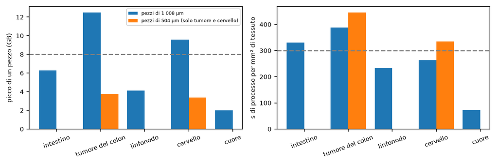

P-3: risorse delle sezioni intere. Sinistra: picco di memoria del pezzo più grande; destra: tempo di processo per mm² di tessuto. Tratteggio: bilancio del documento di progetto.

**Cosa guardare**: con pezzi di 504 µm la memoria sta nel bilancio in tutti i tessuti; il tempo del tumore e dell’intestino resta sopra i 300 s.

## Tutti i giudizi di P-1

| id | tessuto | quantità | rapporto | ± 2 SE | rilevanza | esito |
| --- | --- | --- | --- | --- | --- | --- |
| P-1 | intestino | mean_umi2 | 0.9997 | [0.9895, 1.0100] | [0.98, 1.02] | confermata |
| P-1 | intestino | mean_genes2 | 0.9999 | [0.9898, 1.0099] | [0.98, 1.02] | confermata |
| P-1 | intestino | mean_genes8 | 0.9998 | [0.9908, 1.0089] | [0.98, 1.02] | confermata |
| P-1 | intestino | frac_empty2 | 0.9557 | [0.7927, 1.1186] | [0.705, 1.39] | confermata |
| CP-1 | intestino | mean_umi2_thinned_0.95 | 0.9498 | [0.9400, 0.9595] | [0.98, 1.02] | smentita per difetto |
| P-1 | tumore del colon | mean_umi2 | 0.9970 | [0.9900, 1.0041] | [0.98, 1.02] | confermata |
| P-1 | tumore del colon | mean_genes2 | 0.9969 | [0.9901, 1.0037] | [0.98, 1.02] | confermata |
| P-1 | tumore del colon | mean_genes8 | 0.9970 | [0.9908, 1.0031] | [0.98, 1.02] | confermata |
| P-1 | tumore del colon | frac_empty2 | 1.0393 | [0.9482, 1.1305] | [0.726, 1.27] | confermata |
| CP-1 | tumore del colon | mean_umi2_thinned_0.95 | 0.9472 | [0.9405, 0.9539] | [0.98, 1.02] | smentita per difetto |
| P-1 | stroma | mean_umi2 | 0.9999 | [0.9894, 1.0104] | [0.98, 1.02] | confermata |
| P-1 | stroma | mean_genes2 | 0.9992 | [0.9884, 1.0101] | [0.98, 1.02] | confermata |
| P-1 | stroma | mean_genes8 | 0.9987 | [0.9881, 1.0092] | [0.98, 1.02] | confermata |
| P-1 | stroma | frac_empty2 | 0.9819 | [0.9177, 1.0460] | [0.0957, 1.98] | confermata |
| CP-1 | stroma | mean_umi2_thinned_0.95 | 0.9499 | [0.9399, 0.9599] | [0.98, 1.02] | smentita per difetto |
| P-1 | linfonodo | mean_umi2 | 1.0025 | [0.9972, 1.0078] | [0.98, 1.02] | confermata |
| P-1 | linfonodo | mean_genes2 | 1.0023 | [0.9972, 1.0075] | [0.98, 1.02] | confermata |
| P-1 | linfonodo | mean_genes8 | 1.0023 | [0.9974, 1.0073] | [0.98, 1.02] | confermata |
| P-1 | linfonodo | frac_empty2 | 0.9834 | [0.9409, 1.0258] | [0, 2.73] | confermata |
| CP-1 | linfonodo | mean_umi2_thinned_0.95 | 0.9524 | [0.9474, 0.9575] | [0.98, 1.02] | smentita per difetto |
| P-1 | cervello | mean_umi2 | 1.0162 | [1.0026, 1.0298] | [0.98, 1.02] | indeterminata |
| P-1 | cervello | mean_genes2 | 1.0157 | [1.0024, 1.0291] | [0.98, 1.02] | indeterminata |
| P-1 | cervello | mean_genes8 | 1.0135 | [1.0016, 1.0254] | [0.98, 1.02] | indeterminata |
| P-1 | cervello | frac_empty2 | 0.8868 | [0.7153, 1.0583] | [0, 3.16] | confermata |
| CP-1 | cervello | mean_umi2_thinned_0.95 | 0.9654 | [0.9525, 0.9782] | [0.98, 1.02] | smentita per difetto |
| P-1 | cuore | mean_umi2 | 1.0011 | [0.9914, 1.0108] | [0.98, 1.02] | confermata |
| P-1 | cuore | mean_genes2 | 1.0010 | [0.9914, 1.0105] | [0.98, 1.02] | confermata |
| P-1 | cuore | mean_genes8 | 1.0008 | [0.9920, 1.0096] | [0.98, 1.02] | confermata |
| P-1 | cuore | frac_empty2 | 0.9993 | [0.9827, 1.0158] | [0.485, 1.52] | confermata |
| CP-1 | cuore | mean_umi2_thinned_0.95 | 0.9510 | [0.9418, 0.9603] | [0.98, 1.02] | smentita per difetto |

## Tutti i giudizi di P-2

| tessuto | fascia | blocchi | rapporto | intervallo | esito |
| --- | --- | --- | --- | --- | --- |
| intestino | tissue | 351797 | 0.9993 | [0.9938, 1.0041] | confermata |
| intestino | glass_16_64 | 62833 | 0.9961 | [0.9887, 1.0030] | confermata |
| intestino | glass_64_256 | 102610 | 1.0035 | [0.9976, 1.0094] | confermata |
| intestino | glass_256_512 | 78249 | 1.0068 | [0.9999, 1.0136] | confermata |
| intestino | glass_512plus | 63463 | 1.0177 | [1.0052, 1.0300] | confermata |
| linfonodo | tissue | 346786 | 1.0009 | [0.9891, 1.0139] | confermata |
| linfonodo | glass_16_64 | 71533 | 1.0088 | [0.9960, 1.0226] | confermata |
| linfonodo | glass_64_256 | 135818 | 0.9993 | [0.9859, 1.0116] | confermata |
| linfonodo | glass_256_512 | 76390 | 0.9915 | [0.9739, 1.0097] | confermata |
| linfonodo | glass_512plus | 30523 | 1.0133 | [0.9732, 1.0551] | confermata |
| cuore | tissue | 648987 | 1.0016 | [0.9940, 1.0089] | confermata |
| cuore | glass_16_64 | 14007 | 1.0088 | [0.9758, 1.0402] | confermata |
| cuore | glass_64_256 | 14331 | 0.9875 | [0.9627, 1.0167] | confermata |
| cuore | glass_256_512 | 108 | 1.2593 | [1.1538, 4.0000] | indeterminata |

## P-3 e P-4

Tabella `results/S2.7/S2.7_P3_P4.csv` (una riga per sezione e lato dei pezzi).

# Analisi post hoc

- **PH-1, cervello con 27 semi** (semi k = 9…26 della stessa tabella di P-1, `tools/S2.7_ph_tasks.R`, `/mnt/micron/geo_spatialtrans/S2.7/p1ph/`): UMI per quadratino 1.0044 [0.9948, 1.0139], geni 1.0043 e 1.0036, vuoti 1.054 [0.93, 1.18]: confermate. Lo scarto dell’1.6 % con 9 semi era il caso (con 9 semi il motore di S2.5 dava 43.02 sui due semi riusati e 43.18 sui sette rifatti: revisore dei numeri). Il dubbio sulle tre indeterminate è chiuso.
- **PH-2, sezioni del tumore e del cervello con pezzi di 504 µm** (stessi semi): uscite identiche a quelle con pezzi di 1 008 µm (impronte e file binari uguali: uguaglianza fra divisioni anche su sezioni intere); picco per pezzo 3.8 GB (tumore) e 3.4 GB (cervello); tempo per mm² di tessuto 446 s e 335 s (più bordi fra pezzi da gestire). La memoria oltre il bilancio di P-3a dipende solo dal lato dei pezzi; il tempo no.
- **PH-A1, quanto fondeva la chiave vecchia** (`tools/S2.7_PH_A1.R`, terne vere di un’area di 1 mm² portate alla grandezza dell’area grande, 40 righe estratte a caso): sezione del linfonodo 1.19 % delle terne fuse (fino al 3.0 %), 1.29 % degli UMI con il gene sbagliato; sezione dell’intestino 1.21 % e 1.36 %; sezione del cuore 0.09 % e 0.12 %; quadrato di 9 mm² del linfonodo 0.08 % e 0.09 %. Riguarda solo le simulazioni in un pezzo solo di S2.6 su aree grandi; nessuna previsione di S2.6 usava i geni.

# Revisione avversariale

Due sotto-agenti con codice proprio (2026-11-11):

- **Numeri**: G-2 byte per byte (75 coppie, 0 differenze); ingressi di P-1 per tumore e cervello dai file a 2 e 8 µm (54 esecuzioni, scarto 0); i 24 giudizi di P-1 e i 6 di CP-1 identici entro 3e-14; P-2 del linfonodo identico (2e-16) e confermato anche con un bootstrap suo; P-3 e P-4 dai json identici (4 smentite su 10). Rilievi: lo scarto del cervello (chiuso da PH-1); lo 0.3 % degli UMI cade nella cornice fuori dall’area di cattura, uguale nei due motori (nessun effetto). Deviazioni dichiarate dal revisore: quota troncata letta dai json, non ricalcolata; bootstrap con semi suoi.
- **Codice**: nessuna estrazione dipende dalla divisione o dai processi; distanza dal bordo identica a S2.5 nei casi provati (3 tessuti su 6, livelli sintetici) e argomento dell’alone corretto; nascita, spostamento, seconda coda, cattura, fondo, somma a 8 µm, verità geometrica e conservazione come S2.5. Rilievi: (D-01) il fondo usa il fattore di striscia tagliato al tetto (effetto dell’ordine di 1e-6; dichiarato sotto); (D-02) `frame` cambia anche la maschera della distanza dal bordo, non solo la riflessione (nessun effetto sulle previsioni, che usano il riquadro predefinito); (R-01) `truth$layers$stripes$M` resta il massimo grezzo, la sovra-generazione usata è M*; (R-02) batteria e mutanti provano solo l’invarianza alla divisione: un mutante con tre errori di legge passa il gruppo a, quindi la legge rispetto a S2.5 è provata da P-1, P-2 e da questa lettura; (R-03) nel gruppo a l’alone non tronca mai (lo esercitano il test b, il mutante M3 e G-2); (R-04) due controlli veri per costruzione; (R-05) comandi e descrizione del mutante M8 scritti male nella pre-registrazione; (R-06) l’impronta della ripresa non contiene la versione del codice; (R-07) la frase «meno dell’1 per mille» sulla varianza è ottimista (stima fino a 2.5 per mille nel linfonodo). Tutti accolti: dichiarati qui o rinviati (BL-246…BL-248); nessun esito cambia.

# Cosa è girato

- Commit: cancelli `371a1ea`, ok di Luca `12aec8a`, codice `d5e0cfa`, correzioni `c8d6c5e`; chiusura nel commit «S2.7: esiti, revisione, In breve, DEC-076, BACKLOG, report».
- Script: `R/05b6_simulate_visium_hd_pieces.R`; `tools/S2.7_run.R`, `S2.7_tasks.R`, `S2.7_sched.py`, `S2.7_identity.R`, `S2.7_p1_analysis.py`, `S2.7_section_measures.py`, `S2.7_md5.sh`, `S2.7_mutants.py`, `S2.7_PH_A1.R`, `S2.7_ph_tasks.R`, `S2.7_E0_stripes.R`, `S2.7_report_parts.py`; misure di S2.5 con `tools/S2.5_stats.py`.
- Semi: G-2 da 20261218; P-1 da 20261219 (tabella 27 × 2 × 6, PH-1 dalla stessa tabella); sezioni da 20261220; bootstrap 20261221 (B = 2000).
- Durata e risorse: vedi «Deviazioni dichiarate» (D-5).
- md5: 192 file letti identici prima e dopo (`results/S2.7/S2.7_md5_before.txt`, `S2.7_md5_after.txt`).

## Perimetro

Una funzione nuova, `simulate_visium_hd_pieces()` (file `R/05b6_simulate_visium_hd_pieces.R`), accanto a `simulate_visium_hd()` di S2.5, che resta come riferimento fino al consolidamento dello Step 2. Modifiche al codice esistente, tutte compatibili: ripiego della triangolazione in `R/05b3` (BL-241; identico dove la triangolazione riesce), argomento facoltativo dei flussi casuali in `simulate_cell_profiles()` (identico quando non si usa). Architettura in S2.7: come si costruisce la simulazione a pezzi (DEC-074), decisione tecnica dell’agente:

1. **Divisione.** Griglia di Visium HD dell’area intera come `build_hd_grid()`; pezzi quadrati di lato T, multiplo di 56 µm (dunque di 8 µm: 504, 1 008, 2 016 µm), allineati all’origine della griglia. Una cellula appartiene al pezzo che contiene il suo centro (`cell_df$x`, `cell_df$y`); un quadratino al pezzo che contiene il suo centro.
2. **Casualità legata a tessere fisse.** Un reticolo di tessere di 56 µm, ancorato all’origine della griglia e indipendente da T: profili, nascita e spostamento si estraggono con un flusso per tessera di cellule; assottigliamento e fondo con un flusso per tessera di quadratini; il rumore del campo di variabilità fine con un flusso per tessera della sottogriglia di 0.5 µm. Dentro una tessera l’ordine è quello globale (cellule nell’ordine di `cell_df`; terne ordinate per quadratino, cellula, gene). Per costruzione il risultato non dipende né da T né dal numero di processi.
3. **Tre fasi.** (0) Per pezzo: area di tessuto e verità geometrica dei suoi quadratini (territori di tutte le cellule che li toccano). Poi, sull’area intera: strisce (una sola realizzazione, normalizzata sul tessuto dell’area intera) e composizione dei geni del fondo. (A) Per pezzo: profili, nascita e spostamento delle sue cellule; i trascritti che arrivano nei quadratini di un altro pezzo si scrivono per il pezzo di arrivo. (B) Per pezzo: cattura dei trascritti arrivati nei suoi quadratini (suoi e ricevuti), fondo, somma a 8 µm. Infine si cuciono le uscite nel formato di `simulate_visium_hd()`. Ogni fase scrive un file per pezzo (rilanciabile).
4. **Seconda coda sull’area intera.** Con `frame_open = FALSE` (area di cattura intera) chi esce dalla griglia è perso; con `frame_open = TRUE` (aree ritagliate) la coda si ripiega sui lati del riquadro dell’area intera (`frame`, predefinito il riquadro di regioni e territori come oggi), non del pezzo.
5. **Distanza dal bordo del tessuto alla nascita** su una finestra del pezzo allargata di H = 25 D (D = scala della zona di bordo del tessuto, 6.9-24.7 µm): dove la distanza vera supera H la probabilità della zona di bordo, exp(-d/D) < 1.4e-11, è sotto il più piccolo numero che il generatore può estrarre (2.3e-10), quindi la scelta del modo è la stessa della distanza calcolata sull’area intera.
6. **Sovra-generazione** (BL-242): decisione 1 sotto.

Che cosa si misura: G-2 (uguaglianza fra divisioni), P-1 (stessa legge del motore di S2.5 su aree di 1 mm²), P-2 (sezioni intere contro le sezioni in un pezzo solo di S2.6), P-3 (tempo e memoria delle cinque sezioni intere), P-4 (quota troncata dal tetto).

## Attese pre-registrate

Commit dei cancelli: `371a1ea` (perimetro, stime di preparazione, cancelli e S2.7: come si costruisce la simulazione a pezzi (DEC-074)). Ok di Luca sulle previsioni P-1…P-4, sulle soglie, sui semi, sulla controprova e sul calcolo di circa 21 ore-processo: 2026-11-10, «Ok, come proposte (Recommended)». Decisione 1: «Tetto fisso per tessuto (Recommended)», registrata in S2.7: tetto fisso della sovra-generazione delle strisce per tessuto (DEC-075).

Semi (Mersenne-Twister, `sample.int(1e8, n)`): G-2 da 20261218 (tessuto A1…A6, poi sezione del cuore); P-1 da 20261219 (tessuto, motore S2.5 / pezzi, seme k); sezioni di P-2…P-4 da 20261220 (sezione A1, A2, A4, A5, A6); bootstrap B = 2000, seme 20261221. Per P-1 il motore di S2.5 riusa i suoi 2 semi di S2.5 (k = 0, 1, `S2.5/panel/main/`) e aggiunge i semi nuovi. Processi: al più 20 a un thread (guardia della temperatura come in S2.6; totale con gli altri utenti al più 28). Uscite in `/mnt/micron/geo_spatialtrans/S2.7/` (un file per esecuzione e per pezzo), tabelle in `results/S2.7/`.

### Cancelli (al massimo 5)

| id | controllo | tolleranza | comando |
| --- | --- | --- | --- |
| G-1 | **batteria** `R/testing/test_S2.7.R`: (a) uguaglianza bit per bit fra pezzo solo e pezzi (T = 56, 112, 168 µm) e fra 1 e 3 processi su livelli piccoli dei sei tessuti, con tutti gli strati accesi e co… | identità esatte; mutanti 8/8 | `R_LIBS_SITE=/nonexistent R_LIBS_USER=/nonexistent Rscript --vanilla R/testing/test_S2.7.R`; `tools/S2.7_mutants.py` |
| G-2 | **uguaglianza fra divisioni su aree grandi**: quadrati di 4 mm² dei sei tessuti (livelli `pc_*_2000um` di S2.6, k = 0, tutti gli strati, `frame_open = TRUE`) e sezione intera del cuore (`frame_open = … | md5 identici di UMI per quadratino, matrici a 2 e 8 µm, tabelle di verità | `tools/S2.7_identity.sh` |
| G-3 | **invarianti di ogni esecuzione**: conservazione per cellula e totale, inviati = ricevuti, copertura dei quadratini una volta, 8 µm = somma dei 2 µm, nessun NA, conteggio dei ripieghi della triangolaz… | identità | `tools/S2.7_check.R` |
| G-4 | **integrità**: md5 dei file letti prima e dopo (livelli di S2.5 e S2.6, profili, matrici vere delle sezioni); batterie di S2.1…S2.6 invariate; `git diff` di `R/` limitato ai file dichiarati nel perime… | identità | `tools/S2.7_md5.sh before / after`; batterie |
| G-5 | **revisione avversariale**: sotto-agenti con codice proprio ricalcolano (a) le uguaglianze di G-2 dai file; (b) gli ingressi e gli esiti di P-1 da due tessuti; (c) le fasce del vetro e il tessuto di u… | quantità deterministiche entro 1e-9 relativo; ogni discrepanza è un dubbio | sotto-agenti, report |

### Previsioni

Esito: stima ± 2 errori standard (o intervallo del bootstrap) tutta dentro l’intervallo di rilevanza, confermata; tutta fuori, smentita; a cavallo, indeterminata. Il cuore non è qui un controllo negativo del Voronoi isotropo: nessuna misura dipende dalla forma delle cellule.

| id | quantità | tessuti | atteso | intervallo di rilevanza | fonte dell’intervallo | 2 errori standard tipici |
| --- | --- | --- | --- | --- | --- | --- |
| P-1 | **stessa legge del motore di S2.5**: rapporto pezzi (T = 504 µm) / S2.5 delle medie sui semi di: UMI per quadratino di 2 µm, geni per quadratino di 2 µm, geni per blocco di 8 µm (in tessuto, misure di… | A1-A6 (24 giudizi) | confermata in tutti (stessa legge; il tetto cambia la varianza della cattura di meno dell’1 per mille); cuore possibile indeterminata | UMI e geni **[0.98, 1.02]**; quota di vuoti: ampiezza relativa dell’intervallo corretto del valore vero del tessuto | UMI e geni: margine di Luca per le giunture di S2.6 (precisione del lato simulato in S2.5); vuoti: intervalli corretti di R7 (intervalli corretti dei valori veri (DEC-061)), uno scarto più piccolo non… | circa 1 % (E-1; semi scelti per questo) |
| P-2 | **sezione intera a pezzi (T = 1 008 µm) / sezione in un pezzo solo di S2.6** (motore di S2.5): UMI medio per blocco di 8 µm nel tessuto; vetro a 16-64, 64-256, 256-512, oltre 512 µm dal tessuto (defin… | intestino, linfonodo (livello originale, ripiego della triangolazione), cuore (14 giudizi; il cuore non ha vetro oltre 512 µm) | confermata in tutti (nessuna coda ripiegata nei pezzi, nessun bordo doppio) | tessuto [0.98, 1.02]; vetro [0.8, 1.25] | tessuto: come P-1; vetro: Luca, 2026-10-31 (R5 CP-2), usato in S2.4 P-5 e S2.6 P-6 | bootstrap delle tessere di 500 µm (S2.6: tessuto circa 1 %, vetro 3-30 %) |
| P-3 | **risorse delle cinque sezioni intere a pezzi** (T = 1 008 µm): (a) picco di memoria del processo di un pezzo, massimo sui pezzi; (b) tempo di processo per mm² di tessuto (somma delle fasi 0, A, B) | 5 sezioni (10 giudizi) | (a) confermata 5/5 (tumore circa 6-7 GB: indeterminata possibile); (b) confermata 5/5 (tumore circa 240 s) | (a) [0, 8 GB]; (b) [0, 300 s] | bilancio del documento di progetto, sezione 12 | un solo seme: nessun errore Monte Carlo, si dice |
| P-4 | **quota troncata dal tetto** (opzione (a) della decisione 1, scelta da Luca): UMI attesi persi per il taglio dei fattori sopra M* / UMI attesi, sulle cinque sezioni | 5 sezioni | confermata 5/5 (atteso circa 1e-6) | [0, 0.002] | un decimo del margine del 2 % di P-1 | calcolo esatto dai fattori: nessun errore Monte Carlo |

### Controprova

- **CP-1, P-1 vede uno scarto quando c’è?** Le uscite dei pezzi di P-1 assottigliate con probabilità 0.95 (equivale esattamente a una cattura più bassa del 5 %) devono dare UMI per quadratino **smentita per difetto in 6/6**. Dove non lo è, lì P-1 non ha potere.

### Misure (senza intervallo)

- Picco di memoria e tempo di orologio del processo principale delle sezioni; tempo per fase; trascritti scambiati fra pezzi; numero di ripieghi della triangolazione per sezione; quadratini sopra il tetto.
- Confronto con S2.6: costo per mm² rispetto ai pezzi con bordo di S2.6; trascritti generati rispetto alla sezione del linfonodo in un pezzo solo (496 milioni).
- Descrittive di BL-237: area A1_r1 con il riquadro della finestra di R2 invece del riquadro delle regioni (vetro vicino al lato della finestra).
- Descrittive delle sezioni intere contro le sezioni vere (come S2.6), anche per tumore e cervello.

### Stima dei tempi (dell’agente, dai tempi misurati in S2.5 e S2.6)

Sviluppo e batteria circa 1 ora-processo. G-2: quadrati di 4 mm², tre divisioni, circa 3.2 ore-processo (S2.6: 238-1 190 s per quadrato in un pezzo solo, per circa 0.9 per il tetto); sezione del cuore, tre esecuzioni, circa 1.7. P-1: circa 6.3 (S2.5: 60-230 s per area e seme; 81 semi per motore in tutto, meno i 12 già fatti). P-2…P-4: le cinque sezioni a pezzi, circa 8.3 (intestino, linfonodo, cuore da S2.6 in un pezzo solo per il tetto; tumore e cervello dai quadrati di 9 mm²). In tutto **circa 21 ore-processo**; con 16-20 processi circa 3 ore di orologio, se la macchina è libera.

## Correzioni prima dei calcoli e anomalie

- **C-0, cartella del motore di S2.5 in P-1.** La pre-registrazione scrive che il motore di S2.5 riusa i suoi semi k = 0, 1 da `S2.5/panel/main/`. Quella variante del pannello è girata con il fattore di profondità di S2.2, non con quello predefinito del simulatore (ritarato in S2.5 con la regola R-2). Il confronto della legge va fatto con il predefinito in entrambi i motori: si riusano gli stessi semi della variante `main_r2` (stessi semi di `main`, fattore predefinito; verificato: i valori di `S2.5_R2_depth.csv` coincidono con `visium_hd_depth_factor()`). È un errore di scrittura della pre-registrazione; previsioni e intervalli non cambiano.
- **C-1, mutanti, prima stesura 6/8.** Due mutanti erano scritti male: (M5) spostare l’origine del rumore del campo trasla il campo allo stesso modo in ogni finestra, quindi non è un difetto; riscritto come rumore nullo fuori dalla finestra (convoluzione troncata ai lati), che è il difetto vero da escludere; (M7) la composizione del fondo per pezzo non si vede nel linfonodo e nel cuore, dove il fondo è zero; i mutanti girano ora anche sul cervello. Seconda stesura: 8/8.
- **C-2, test aggiunti alla batteria prima del verdetto.** (1) La seconda coda con `frame_open` arriva sul vetro a oltre 450 µm dal tessuto (rileva il mutante M8, che le altre uguaglianze non vedono perché la ripiegatura sbagliata è la stessa in ogni divisione). (2) Gruppo h, anomalia A-1 (sotto).
- **C-3, lentezza della fase B.** Nella prima esecuzione di G-2 la fase B di un pezzo grande (pezzo solo di 4 mm²) superava i 24 minuti: una ricerca `findInterval()` per tessera su un vettore di decine di milioni di elementi, convertito ogni volta. Sostituita con una sola ricerca vettoriale (fase A e fase B); risultati identici (batteria e valori dei test uguali a prima). Tutte le esecuzioni di G-2 e P-1 sono state cancellate e rifatte con il codice del commit `d5e0cfa`.

# Anomalie trovate durante il lavoro

- **A-1, chiave unica oltre 2^53 nella funzione di S2.3.** `place_and_move_transcripts()` raggruppava le terne (quadratino, cellula, gene) con la chiave `key * (G + 1) + gene`, con key = (quadratino - 1) n + (cellula - 1) e G circa 18 000-19 000 geni. Il valore è esatto solo sotto 2^53 (9.0e15), cioè quando quadratini × cellule × geni < 9e15. Sulle aree di 1 mm² del pannello (quadratini × cellule fino a 1.7e10) è esatto; sulle sezioni intere in un pezzo solo di S2.6 (intestino 3.7e12, linfonodo 8.3e12, cuore 5.6e11 quadratini × cellule) e sul quadrato di 9 mm² del linfonodo (8.0e11) no: geni diversi della stessa cellula nello stesso quadratino potevano fondersi in uno (gli UMI restano, cambia il gene). Nessuna previsione di S2.6 usava i geni (solo UMI, tempi, memoria; la somiglianza fra geni attraverso le giunture era sui quadrati di 4 mm², esatti). Corretta con il confronto delle coppie consecutive (identica dove la chiave era esatta: batterie di S2.1…S2.6 invariate); la funzione nuova usa chiavi intere esatte. Quanto fondeva: analisi post hoc PH-A1 (`tools/S2.7_PH_A1.R`).

## Deviazioni dichiarate

- **D-1, rete**: la VPN è caduta fra le due giornate; dal 2026-11-11 si è lavorato dal secondo accesso allo stesso server (lesexp-ts).
- **D-2, errori di scrittura della pre-registrazione** (dalla revisione, R-05 e R-07): il comando di G-2 è `tools/S2.7_identity.R` (non `.sh`); i controlli di G-3 sono scritti dalla funzione nei json di `tools/S2.7_run.R` (non esiste `tools/S2.7_check.R`); il mutante M8 ripiega la seconda coda sul riquadro dei punti di nascita della tessera, non del pezzo; l’effetto del tetto sulla varianza della cattura arriva a circa 2.5 per mille (stima del revisore), non «meno dell’1 per mille». Nessun esito cambia.
- **D-3, differenze di legge non scritte nel perimetro** (revisione, D-01, D-02): il fondo è Poisson(b c) con c tagliato al tetto, come la cattura (quadratini toccati: circa uno su 100 000); con `frame_open` il riquadro dato in `frame` vale come bordo aperto anche per la distanza dal bordo del tessuto, oltre che per la riflessione. Coerenti con il modello; vanno nella documentazione al consolidamento (BL-248).
- **D-4, misure descrittive non fatte**: BL-237 (A1_r1 con il riquadro della finestra) non è girata; resta aperta (BL-248).
- **D-5, calcolo**: 26 ore-processo per le esecuzioni pre-registrate (G-2 8.7, P-1 7.5, sezioni 9.9) contro le 21 stimate, più 9 ore-processo post hoc e circa 1.5 ore della prima esecuzione cancellata (C-3); orologio delle esecuzioni pre-registrate circa 4 ore (2026-11-10, 18:07-22:17), al più 16 processi, temperatura massima 82 °C.

# Appendice: da dove vengono i numeri del riassunto

| frase del riassunto | fonte (tabella o file, riga) | valore letto |
| --- | --- | --- |
| file identici bit per bit a pezzi e in un pezzo solo | `S2.7_G2_identity.csv`; `S2.7_PH2_md5.txt` | 210 su 210 identici; tumore e cervello 504 = 1 008 µm |
| fra i pezzi passano da 5 a 52 milioni di trascritti | json delle sezioni, `n_sent` | 4.56 milioni (cuore), 52.3 milioni (cervello) |
| UMI e geni entro il 2 % nei sei tessuti | `S2.7_P1.csv` | 21 confermate, 3 indeterminate (cervello) |
| cervello +1,6 % con nove ripetizioni, 0,4 % con 27 | `S2.7_P1.csv`, `PH1/S2.7_P1.csv`, A5 mean_umi2 | 1.0162; 1.0044 |
| cattura abbassata del 5 % vista in 6 tessuti su 6 | `S2.7_P1.csv`, CP-1 | 6 smentite per difetto |
| tessuto entro l’1 %, vetro lontano entro il 2 % | `S2.7_section_A1.csv`, `A4`, `A6` | tessuto 0.9993, 1.0009, 1.0016; ≥ 512 µm 1.0177, 1.0133 |
| prima a pezzi il vetro lontano aveva la metà | `results/S2.6/S2.6_section_A1.csv`, `A4` | 0.548; 0.487 |
| tumore 12,5 GB, cervello 9,6 con pezzi da 1 mm; sotto 4 con mezzo mm | `S2.7_P3_P4.csv` | 12.49, 9.58; 3.78, 3.39 |
| tumore 6 minuti e mezzo, intestino 5 e mezzo per mm² | `S2.7_P3_P4.csv`, s_per_mm2_tissue | 388.5 s; 330.5 s |
| una sezione del tumore 3 ore e mezza di processore, mezz’ora con 8 processi | `S2.7_P3_P4.csv`, sec_A2_p1008w8 | 12 851 s; 1 894 s |
| da un sesto a due terzi del tempo nel calcolo delle coperture | json delle sezioni, stage_time_sum_s fase 0 | 17 % (tumore) - 69 % (cuore) |
| 265 milioni di trascritti invece di 496 | json di sec_A4_p1008w8 `n_generated`; `S2.6/q3/one_A4/run.json` | 264 853 011; 496 057 390 |
| un quadratino su 100 000, meno di 6 UMI su un milione | `S2.7_P3_P4.csv` | 142-267 quadratini; quota massima 5.3e-6 |
| circa l’1,3 % dei trascritti con il gene sbagliato | `S2.7_PH_A1.txt` | linfonodo 1.29 %, intestino 1.36 % |
| 26 ore-processo contro 21, più 9 post hoc; 4 ore; 16 processi; 82 °C | json delle esecuzioni; `sched_*.log` | 8.7 + 7.5 + 9.9; 9.0; 18:07-22:17; 16; 82.1 °C |